# Peat

# ’Start Issue Ticket to copy SiteID-Site_name

# ’Read function

```r
#'Change hard path to relative pathway for easy sharing
source('~/soilDataR/R/processData_Treat2015_1.R')
meta<- processData_Treat2015(dir='/Treat_2015', verbose=FALSE)
```

# Site locations

## Lat-lon map

[figure not shown]

```r
mapWorld <- borders("world", colour="gray80", fill="gray80") # create a layer of borders
#ggplot() + mapWorld
ggplot(unique(meta$site[, c('lat', 'long')])) +
  mapWorld +
  geom_hex(aes(x=long, y=lat), bins=200) +
  scale_fill_gradient(trans='log10')
```

```r
countryCounts <- ddply(subset(meta$site, !is.na(lat+long)), 'country',  summarize, count=length(unique(site_name)))
```

```r
names(countryCounts)[1] <- 'region'
countryCounts$region <- as.character(countryCounts$region)
countryCounts$region[grepl('united States', countryCounts$region)] <- 'USA'

map.world <- map_data(map="world")

cat('These countries are unknown to the map\n')
```

```
## These countries are unknown to the map
```

```r
kable(subset(countryCounts, ! region %in% map.world$region))
```

|  | region | count |
| --- | --- | --- |
| 4 | United States | 12 |

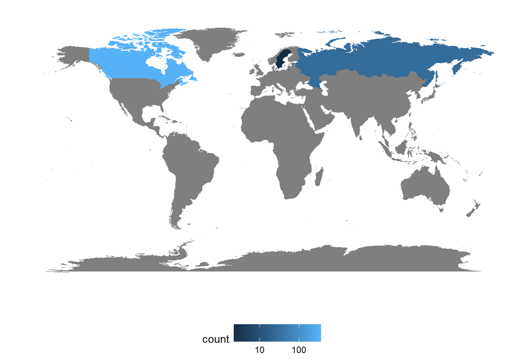

```r
missingCountries <- data.frame(region=setdiff(map.world$region, countryCounts$value), count=NA)
countryCounts <- rbind(countryCounts, missingCountries)
#map.world <- merge(map.world, countryCounts, all=TRUE)
ggplot(countryCounts, aes(map_id = region)) +
  geom_map(aes(fill=count), map=map.world) +
  expand_limits(x = map.world$long, y = map.world$lat) +
  coord_cartesian(xlim=c(-180,180), ylim=c(-90,90)) +
  scale_x_continuous(breaks = NULL) +
  scale_y_continuous(breaks = NULL) +
  scale_fill_gradient(trans='log10') +
  labs(x = "", y ="") +
  theme(legend.position = "bottom",
        panel.background = element_blank())
```

0 sites with no known country nor lat-lon.

## Site count by country map (include sites w/ lat-lon)

```r
countryCounts <- ddply(meta$site, 'country', summarize, count=length(unique(siteID)))
names(countryCounts)[1] <- 'region'
countryCounts$region <- as.character(countryCounts$region)
countryCounts$region[grepl('United States', countryCounts$region)] <- 'USA'

map.world <- map_data(map="world")

missingCountries <- data.frame(region=setdiff(map.world$region, countryCounts$region), count=NA)
setdiff(countryCounts$region, map.world$region)
```

```
## character(0)
```

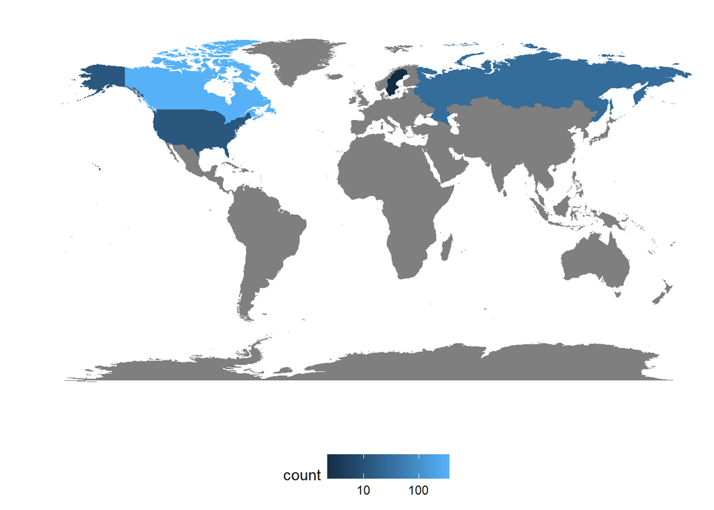

```r
countryCounts <- rbind(countryCounts, missingCountries)
#map.world <- merge(map.world, countryCounts, all=TRUE)
ggplot(countryCounts, aes(map_id = region)) +
  geom_map(aes(fill=count), map=map.world) +
  expand_limits(x = map.world$long, y = map.world$lat) +
  coord_cartesian(xlim=c(-180,180), ylim=c(-90,90)) +
  scale_x_continuous(breaks = NULL) +
  scale_y_continuous(breaks = NULL) +
  scale_fill_gradient(trans='log10') +
  labs(x = "", y = "") +
  theme(legend.position = "bottom",
        panel.background = element_blank())
```

# Summary of measurements

```r
table(meta$meta$dataset_description)
```

```
## < table of extent 0 >
```

All measurements are on oven dry soils and in mass percent where percent noted.

## Soil organic carbon stock

- *soc* calculated soil carbon stock of layer/profile

## Bulk density

- *bd_samp* is the bulk density of the <2mm (fine earth) fraction, in which the mass is expressed on an oven-dry (105 deg) basis. This is the best form of Db for the most uses.
- *bd_tot* is the whole soil bulk density, includes fine earth fraction and rocks.
- *bd_whole* is the bulk density of the whole soil (coarse frags, if present, included), expressed on a 1/3 bar moisture content (a little drier than typical site moist, but not oven-dry). It is collected by the clod method. For a variety of reasons, including the presence of water, possible coarse frags, and the tendency of clods to cleave along pore spaces, this will overestimate Db relative to bd_samp. The SSL standard method here is 4A1d if you want to look it up.
- *bd_other* is, for data contributed by NRCS SSL, the bulk density of the fine earth fraction, but expressed on a site moist condition. It is collected by a volumetric core, but given the presence of some water, will probably usually be an overestimate relative to the bd_samp. This corresponds to the SSL standard method 4A3a. For datasets contributed by sources other than NRCS, bd_other is anyone’s guess. Hopefully specified in the associated bd_method variable, or the metadata sheet for that dataset.

Reasonable BD minimum 0.03 or lower and maximum 2.7 g cm-3.

[figure not shown]

```r
plot.df <- merge(subset(meta$sample, grepl('^bd_', variable) &
                          value > 0 & value < 2.7), meta$measurement)
ggplot(plot.df) +
  geom_histogram(aes(x=value, y=..density..)) +
  #scale_x_log10() +
  facet_wrap(type~units)
```

```r
summary(subset(meta$sample, grepl('^bd_', variable) &
                          (value <= 0 | value > 2.7)))
```

```
##    fieldID            variable             value    uncertainty
##  Length:3           Length:3           Min.   :0   Min.   : NA
##  Class :character   Class :character   1st Qu.:0   1st Qu.: NA
##  Mode  :character   Mode  :character   Median :0   Median : NA
##                                        Mean   :0   Mean   :NaN
##                                        3rd Qu.:0   3rd Qu.: NA
##                                        Max.   :0   Max.   : NA
##                                                    NA's   :3
```

```r
nrow(plot.df)
```

```
## [1] 101384
```

Number of samples for BD 101384.

## Carbon (mostly organic)

- *c_tot* carbon concentration in a dry combustion analysis, sometimes include inorganic carbon
- *oc* organic carbon concentration from either acidified (to remove carbonates) and then ran on dry combustion analyizer, or (more common) wet oxidation ‘Walkly-Black’ dicromate oxidation, chemical digest for organic carbon; old methods 1930-1990s tends to over estimate it in certain soils. pH below 7 c_tot generally == oc otherwise you might have carbonates
- *loi* loss on ignition uncorrected for C:organics, generally close to half for O-horizon, C about a third of the LOI for lower horizons.

[figure not shown]

```r
ggplot(merge(subset(meta$sample, grepl('^(c_|oc|loi|soc)', variable) & value > 0),
             meta$measurement)) +
  geom_histogram(aes(x=value, y=..density..)) +
  scale_x_log10() +
  facet_wrap(type~units)
```

```r
summary(subset(meta$sample, grepl('^(c_|oc|loi)', variable) & (value < 0)))
```

```
##    fieldID            variable             value      uncertainty
##  Length:0           Length:0           Min.   : NA   Min.   : NA
##  Class :character   Class :character   1st Qu.: NA   1st Qu.: NA
##  Mode  :character   Mode  :character   Median : NA   Median : NA
##                                        Mean   :NaN   Mean   :NaN
##                                        3rd Qu.: NA   3rd Qu.: NA
##                                        Max.   : NA   Max.   : NA
```

## Carbon (inorganic)

Percent inorganic carbon in a sample.

## Nitrogen

- *n_tot* most N is organic mass percent dry weight, probably estimated by dry combustion (Dumas methods), sometimes also Kjeldahl digestion converts N to nitrate and then measures nitrate.

[figure not shown]

```r
ggplot(merge(subset(meta$sample, grepl('^n_', variable) & value > 0),
             meta$measurement)) +
  geom_histogram(aes(x=value, y=..density..)) +
  scale_x_log10() +
  facet_wrap(type~units)
```

## pH

- *ph_cacl* 1:2 Soil-CaCl2 suspension
- *ph_h2o* 1:1 Soil-water suspension
- *ph_other* non-standard catch all

## Sand, clay, slit, and percent coarse fragement content

Partical size analysis. Methods might not be completely annotated.

- *wpg2* coarse fragment (>2mm) content by weight
- *sand_tot_psa* percentage of sand
- *clay_tot_psa* percentage of clay
- *silt_tot_psa* percentage of silt

## Cation exchange capasity and base saturation

- *cat_exch* cation exchange capasity [[TODO: Ask Luke N about this variable]]
- *cec_sum* cation exchange capsity (sum of cations)
- *ecec* effective cation exchange capsity
- *bs* base saturation (NH4OAc at pH 7.0)
- *bs_sum* base saturation (sum of cations at pH 8.2)

## Extractable bases

- *ca_al* TODO Luke N, what is this??
- *ca_ext* calcium extractable (SSL: NH4OAc extractable)
- *k_ext* potassium extractable (SSL: NH4OAc extractable)
- *mg_ext* magnesium extractable (SSL: NH4OAc extractable)
- *na_ext* sodium extractable (SSL: NH4OAc extractable)
- *base_sum* sum of NH4OAc extractable bases

## metal (Al, Fe, Mn) extracts

For meta this is only for NRCS data.

- *_dith* Dithionite citrate extractable
- *_ox* Oxalate extractable
- *al_other* and *fe_other* Sodium phyrophospate extractable
- *mn_other* KCl extractable

## Phosphorus

- *p_bray* bray-1 extractable
- *p_ox* oxalate extractable
- *p_other* mehlich3 extractable